# LTOM.01.002 Data Analysis in Community Ecology

## 7.3 Environment within clusters

Instead of working with the original environmental data, we are going to use our new variable ´soil.pca1´ as a synthetic variable that reflects nutrient availabity in our sites. We will test whether the environment differs between samples representing different clusters. For this, we will first make some box plots, then we will perform an anova test and then we will examine whether the assumptions of anova are met.

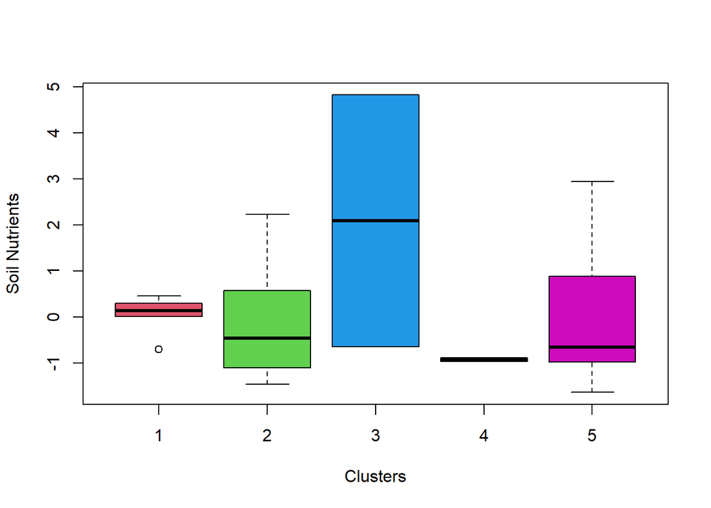

```r
## Using clusters and soil data (Soil pH as an example)

boxplot(soil.pca1 ~as.factor(o.grel),col=2:6,ylab="Soil Nutrients",xlab="Clusters")
```

```r
# ANOVA test

o.anova=aov(soil.pca1 ~ as.factor(o.grel))

anova(o.anova)
## Analysis of Variance Table
##
## Response: soil.pca1
##                   Df Sum Sq Mean Sq F value Pr(>F)
## as.factor(o.grel)  4 11.015  2.7538  1.4044 0.2614
## Residuals         25 49.020  1.9608

# testing anova assumptions:

# 1. residuls of the model must be normally distributed

shapiro.test(resid(o.anova)) # p > 0.05
##
##  Shapiro-Wilk normality test
##
## data:  resid(o.anova)
## W = 0.92643, p-value = 0.03951

# 2. homogeneity of variances among groups

bartlett.test(soil.pca1, as.factor(o.grel)) # p > 0.05
##
##  Bartlett test of homogeneity of variances
##
## data:  soil.pca1 and as.factor(o.grel)
## Bartlett's K-squared = 16.131, df = 4, p-value = 0.002848

## If ANOVA assumptions are not met, we can make non-parametric test
## for example, the Kruskal-Wallis rank sum test

kruskal.test(soil.pca1 ~ as.factor(o.grel))  ## Not significantly different
##
##  Kruskal-Wallis rank sum test
##
## data:  soil.pca1 by as.factor(o.grel)
## Kruskal-Wallis chi-squared = 4.05, df = 4, p-value = 0.3993


## Let's now examine soil pH

o.anova=aov(soil.data$pH.KCl ~ as.factor(o.grel))
shapiro.test(resid(o.anova)) # OK
##
##  Shapiro-Wilk normality test
##
## data:  resid(o.anova)
## W = 0.93286, p-value = 0.05851
bartlett.test(soil.data$pH.KCl, as.factor(o.grel)) # OK
##
##  Bartlett test of homogeneity of variances
##
## data:  soil.data$pH.KCl and as.factor(o.grel)
## Bartlett's K-squared = 3.2945, df = 4, p-value = 0.5098

anova(o.anova) #  significance
## Analysis of Variance Table
##
## Response: soil.data$pH.KCl
##                   Df Sum Sq Mean Sq F value   Pr(>F)
## as.factor(o.grel)  4 6.9907 1.74769   5.042 0.004048 **
## Residuals         25 8.6657 0.34663
## ---
## Signif. codes:  0 '***' 0.001 '**' 0.01 '*' 0.05 '.' 0.1 ' ' 1
TukeyHSD(o.anova) # comparison of pairs, Tukey test
##   Tukey multiple comparisons of means
##     95% family-wise confidence level
##
## Fit: aov(formula = soil.data$pH.KCl ~ as.factor(o.grel))
##
## $`as.factor(o.grel)`
##         diff        lwr       upr     p adj
## 2-1 -0.70000 -1.5645426 0.1645426 0.1545794
## 3-1  0.80500 -0.6067922 2.2167922 0.4667457
## 4-1 -0.11000 -1.5217922 1.3017922 0.9993478
## 5-1  0.26875 -0.6650628 1.2025628 0.9137158
## 3-2  1.50500  0.1843893 2.8256107 0.0198753
## 4-2  0.59000 -0.7306107 1.9106107 0.6864372
## 5-2  0.96875  0.1795342 1.7579658 0.0108067
## 4-3 -0.91500 -2.6440853 0.8140853 0.5388419
## 5-3 -0.53625 -1.9032119 0.8307119 0.7775773
## 5-4  0.37875 -0.9882119 1.7457119 0.9239282
```

> Parametric tests (e.g. ANOVA) are usually more powerful than non-parametric tests (e.g. Kruskal-Wallis) but results are often similar. Test how soil pH is related to clusters using Kruskal-Wallis test.

**Answer**

```r
kruskal.test(soil.data$pH.KCl ~ as.factor(o.grel))
##
##  Kruskal-Wallis rank sum test
##
## data:  soil.data$pH.KCl by as.factor(o.grel)
## Kruskal-Wallis chi-squared = 14.634, df = 4, p-value = 0.005524
```

## 7.4 Environment related to ordination

We ca use the function `envfit` to visually explore the correlation of ordination results with environmental parameters.

[figure not shown]

[output not shown]

[figure not shown]

```r
o.ev=envfit(o.mds,soil.data[,-5])
o.ev
##
## ***VECTORS
##
##            NMDS1    NMDS2     r2 Pr(>r)
## pH.KCl  -0.99949 -0.03192 0.2577  0.020 *
## N..      0.35120 -0.93630 0.1536  0.120
## P.mg.kg -0.42234 -0.90644 0.2055  0.048 *
## K.mg.kg  0.17432 -0.98469 0.0520  0.477
## ---
## Signif. codes:  0 '***' 0.001 '**' 0.01 '*' 0.05 '.' 0.1 ' ' 1
## Permutation: free
## Number of permutations: 999
plot(o.mds$points,pch=o.grel)
plot(o.ev,add=T) # Adding correlations to graph

#Let's add contour levels for pH and NPK
ordisurf(o.mds,soil.data$pH.KCl,add=T)
##
## Family: gaussian
## Link function: identity
##
## Formula:
## y ~ s(x1, x2, k = 10, bs = "tp", fx = FALSE)
##
## Estimated degrees of freedom:
## 4.66  total = 5.66
##
## REML score: 29.02056
ordisurf(o.mds,soil.pca1,add=T,col="green")
```

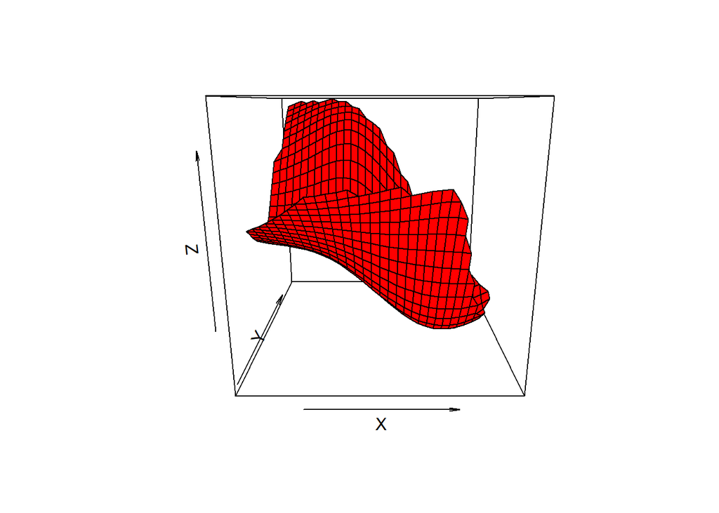

```r
plot(oo,what="persp") # 3D image of study variable (z) along ordination axes (x and y)
```

## 7.5 Constrained ordination

Exploring only variation that can be explained by the selected environmental variables (=constraints). Comparing the taxonomic space vs. environmental space.

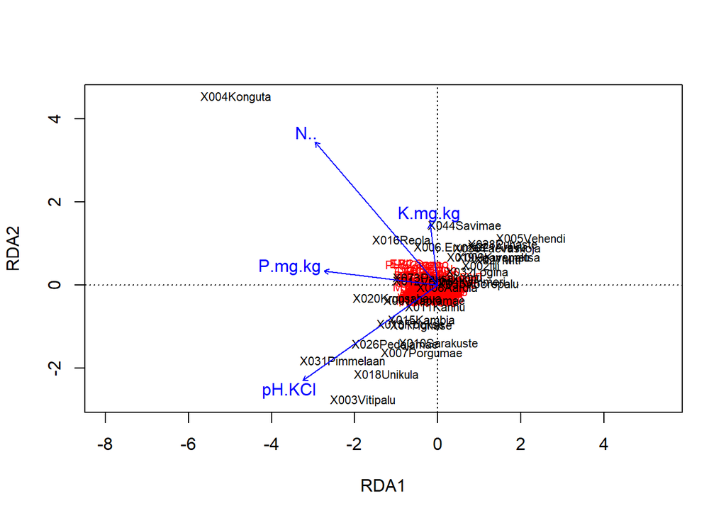

```r
## Linear relationships (similar to PCA)
o.rda=rda(vas.plants~pH.KCl+N..+P.mg.kg+K.mg.kg,data=soil.data,scale=T) # here formulas are suggested, scale=T to put all measures in same units
plot(o.rda)
```

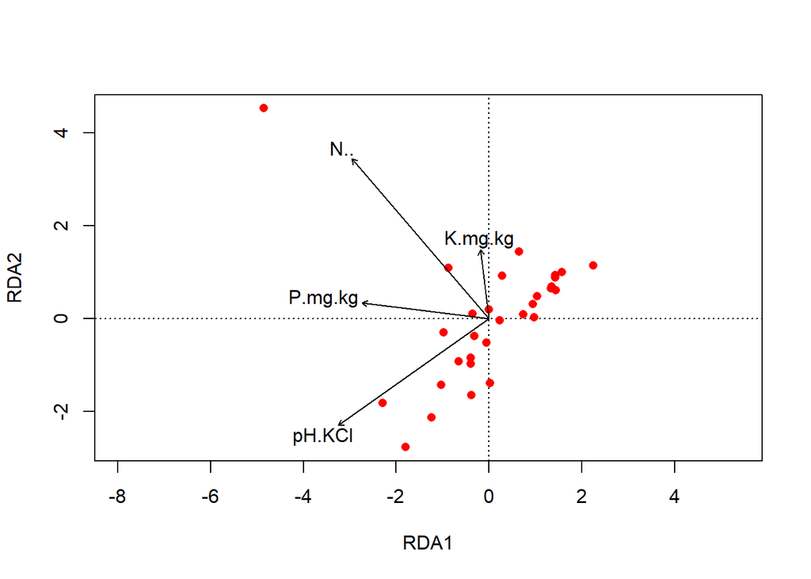

```r
# A simpler plot
plot(o.rda,type="n")
points(o.rda,"sites",col="red",pch=16)
points(o.rda,"cn") # constraints arrow
text(o.rda,"cn")
```

```r
anova(o.rda) # overall significance by randomizations
## Permutation test for rda under reduced model
## Permutation: free
## Number of permutations: 999
##
## Model: rda(formula = vas.plants ~ pH.KCl + N.. + P.mg.kg + K.mg.kg, data = soil.data, scale = T)
##          Df Variance      F Pr(>F)
## Model     4   18.204 1.8714  0.001 ***
## Residual 25   60.796
## ---
## Signif. codes:  0 '***' 0.001 '**' 0.01 '*' 0.05 '.' 0.1 ' ' 1
anova(o.rda,by="mar") # each parameter separately
## Permutation test for rda under reduced model
## Marginal effects of terms
## Permutation: free
## Number of permutations: 999
##
## Model: rda(formula = vas.plants ~ pH.KCl + N.. + P.mg.kg + K.mg.kg, data = soil.data, scale = T)
##          Df Variance      F Pr(>F)
## pH.KCl    1    5.202 2.1391  0.002 **
## N..       1    5.844 2.4033  0.004 **
## P.mg.kg   1    4.311 1.7728  0.021 *
## K.mg.kg   1    2.587 1.0636  0.377
## Residual 25   60.796
## ---
## Signif. codes:  0 '***' 0.001 '**' 0.01 '*' 0.05 '.' 0.1 ' ' 1
anova(o.rda,by="axis") # significance along axes
## Permutation test for rda under reduced model
## Forward tests for axes
## Permutation: free
## Number of permutations: 999
##
## Model: rda(formula = vas.plants ~ pH.KCl + N.. + P.mg.kg + K.mg.kg, data = soil.data, scale = T)
##          Df Variance      F Pr(>F)
## RDA1      1    6.397 2.6306  0.006 **
## RDA2      1    6.331 2.6033  0.001 ***
## RDA3      1    3.454 1.4202  0.236
## RDA4      1    2.022 0.8313  0.707
## Residual 25   60.796
## ---
## Signif. codes:  0 '***' 0.001 '**' 0.01 '*' 0.05 '.' 0.1 ' ' 1

## Canonical Correspondence Analysis is similar, but it assumes unimodal responses (like correspondence analysis did)
o.cca=cca(vas.plants~pH.KCl+N..+P.mg.kg+K.mg.kg,data=soil.data)
anova(o.cca)
## Permutation test for cca under reduced model
## Permutation: free
## Number of permutations: 999
##
## Model: cca(formula = vas.plants ~ pH.KCl + N.. + P.mg.kg + K.mg.kg, data = soil.data)
##          Df ChiSquare      F Pr(>F)
## Model     4    0.8410 1.5721  0.008 **
## Residual 25    3.3434
## ---
## Signif. codes:  0 '***' 0.001 '**' 0.01 '*' 0.05 '.' 0.1 ' ' 1
```

> Plot cca figure and test the overall model, each soil parameter separately and along axes.

**Answer**

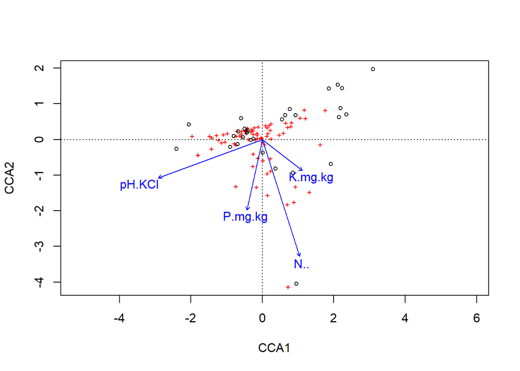

```r
plot(o.cca,type="points")
```

```r
anova(o.cca) # overall significance by randomizations
## Permutation test for cca under reduced model
## Permutation: free
## Number of permutations: 999
##
## Model: cca(formula = vas.plants ~ pH.KCl + N.. + P.mg.kg + K.mg.kg, data = soil.data)
##          Df ChiSquare      F Pr(>F)
## Model     4    0.8410 1.5721  0.005 **
## Residual 25    3.3434
## ---
## Signif. codes:  0 '***' 0.001 '**' 0.01 '*' 0.05 '.' 0.1 ' ' 1
anova(o.cca,by="mar") # each parameter separately
## Permutation test for cca under reduced model
## Marginal effects of terms
## Permutation: free
## Number of permutations: 999
##
## Model: cca(formula = vas.plants ~ pH.KCl + N.. + P.mg.kg + K.mg.kg, data = soil.data)
##          Df ChiSquare      F Pr(>F)
## pH.KCl    1    0.2659 1.9879  0.002 **
## N..       1    0.2371 1.7726  0.069 .
## P.mg.kg   1    0.1970 1.4730  0.061 .
## K.mg.kg   1    0.1319 0.9862  0.480
## Residual 25    3.3434
## ---
## Signif. codes:  0 '***' 0.001 '**' 0.01 '*' 0.05 '.' 0.1 ' ' 1
anova(o.cca,by="axis")
## Permutation test for cca under reduced model
## Forward tests for axes
## Permutation: free
## Number of permutations: 999
##
## Model: cca(formula = vas.plants ~ pH.KCl + N.. + P.mg.kg + K.mg.kg, data = soil.data)
##          Df ChiSquare      F Pr(>F)
## CCA1      1    0.3092 2.3123  0.049 *
## CCA2      1    0.2572 1.9229  0.098 .
## CCA3      1    0.1727 1.2915  0.345
## CCA4      1    0.1019 0.7618  0.782
## Residual 25    3.3434
## ---
## Signif. codes:  0 '***' 0.001 '**' 0.01 '*' 0.05 '.' 0.1 ' ' 1
```

## 7.6 Multivariate ANOVA based on dissimilarities

We can partition the dissimilarities among different sources of variation. In this case, no ordination is used; instead the multivariate space is considered. Significance values are obtained from permutation tests. Also known as PERMANOVA (function `adonis`).

```r
o.adonis=adonis2(vas.plants~pH.KCl+N..+P.mg.kg+K.mg.kg,data=soil.data,method="manhattan",by="mar")
o.adonis
## Permutation test for adonis under reduced model
## Marginal effects of terms
## Permutation: free
## Number of permutations: 999
##
## adonis2(formula = vas.plants ~ pH.KCl + N.. + P.mg.kg + K.mg.kg, data = soil.data, method = "manhattan", by = "mar")
##          Df SumOfSqs      R2      F Pr(>F)
## pH.KCl    1   1070.7 0.09237 3.1563  0.006 **
## N..       1   1094.0 0.09438 3.2249  0.004 **
## P.mg.kg   1    859.0 0.07411 2.5323  0.021 *
## K.mg.kg   1    249.7 0.02154 0.7360  0.656
## Residual 25   8480.7 0.73164
## Total    29  11591.4 1.00000
## ---
## Signif. codes:  0 '***' 0.001 '**' 0.01 '*' 0.05 '.' 0.1 ' ' 1
```

> Use another community distance measure and look if you can get same results.

**Answer**

```r
o.adonis=adonis2(vas.plants~pH.KCl+N..+P.mg.kg+K.mg.kg,data=soil.data,method="bray",by="mar")
o.adonis
## Permutation test for adonis under reduced model
## Marginal effects of terms
## Permutation: free
## Number of permutations: 999
##
## adonis2(formula = vas.plants ~ pH.KCl + N.. + P.mg.kg + K.mg.kg, data = soil.data, method = "bray", by = "mar")
##          Df SumOfSqs      R2      F Pr(>F)
## pH.KCl    1   1.2344 0.15651 5.4397  0.002 **
## N..       1   0.3374 0.04278 1.4868  0.138
## P.mg.kg   1   0.4482 0.05683 1.9753  0.070 .
## K.mg.kg   1   0.1654 0.02097 0.7289  0.659
## Residual 25   5.6732 0.71928
## Total    29   7.8873 1.00000
## ---
## Signif. codes:  0 '***' 0.001 '**' 0.01 '*' 0.05 '.' 0.1 ' ' 1
```

## 7.7 Species Distribution modelling (SDM)

Exploring if species presences/absences are related to some parameters. Can be used to predict changes in distribution if the environment changes (e.g. due to global change).

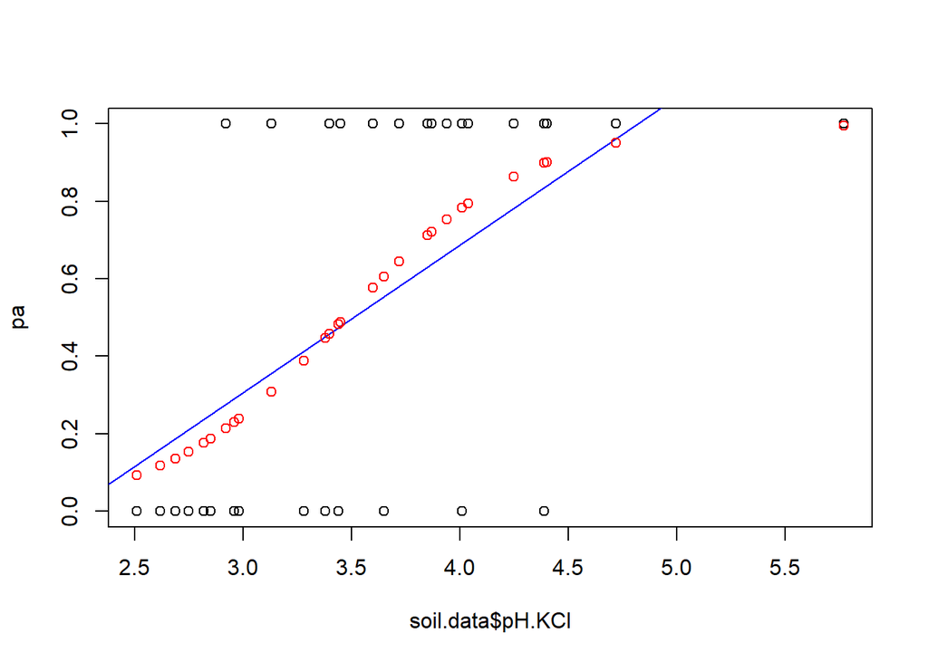

```r
# Selecting a common taxa (SDM cannot work with very rare taxa)
pa=vas.plants[,"RUBUsaxa"]>0 # presence/absence
plot(pa~soil.data$pH.KCl)

m=lm(pa~soil.data$pH.KCl) # linear model
summary(m)
##
## Call:
## lm(formula = pa ~ soil.data$pH.KCl)
##
## Residuals:
##      Min       1Q   Median       3Q      Max
## -0.83734 -0.29760 -0.04173  0.35433  0.72338
##
## Coefficients:
##                  Estimate Std. Error t value Pr(>|t|)
## (Intercept)       -0.8372     0.3987  -2.100  0.04489 *
## soil.data$pH.KCl   0.3814     0.1088   3.506  0.00155 **
## ---
## Signif. codes:  0 '***' 0.001 '**' 0.01 '*' 0.05 '.' 0.1 ' ' 1
##
## Residual standard error: 0.4305 on 28 degrees of freedom
## Multiple R-squared:  0.3051, Adjusted R-squared:  0.2803
## F-statistic: 12.29 on 1 and 28 DF,  p-value: 0.001552
abline(m,col="blue") # does not fit well, we need curvlinera model ...

m=glm(pa~soil.data$pH.KCl,family=binomial)
summary(m)
##
## Call:
## glm(formula = pa ~ soil.data$pH.KCl, family = binomial)
##
## Coefficients:
##                  Estimate Std. Error z value Pr(>|z|)
## (Intercept)       -8.2388     3.1321  -2.630  0.00853 **
## soil.data$pH.KCl   2.3744     0.8891   2.671  0.00757 **
## ---
## Signif. codes:  0 '***' 0.001 '**' 0.01 '*' 0.05 '.' 0.1 ' ' 1
##
## (Dispersion parameter for binomial family taken to be 1)
##
##     Null deviance: 41.455  on 29  degrees of freedom
## Residual deviance: 30.007  on 28  degrees of freedom
## AIC: 34.007
##
## Number of Fisher Scoring iterations: 5
pr.glm=predict(m,type="response")

points(pr.glm~soil.data$pH.KCl,col="red")
```

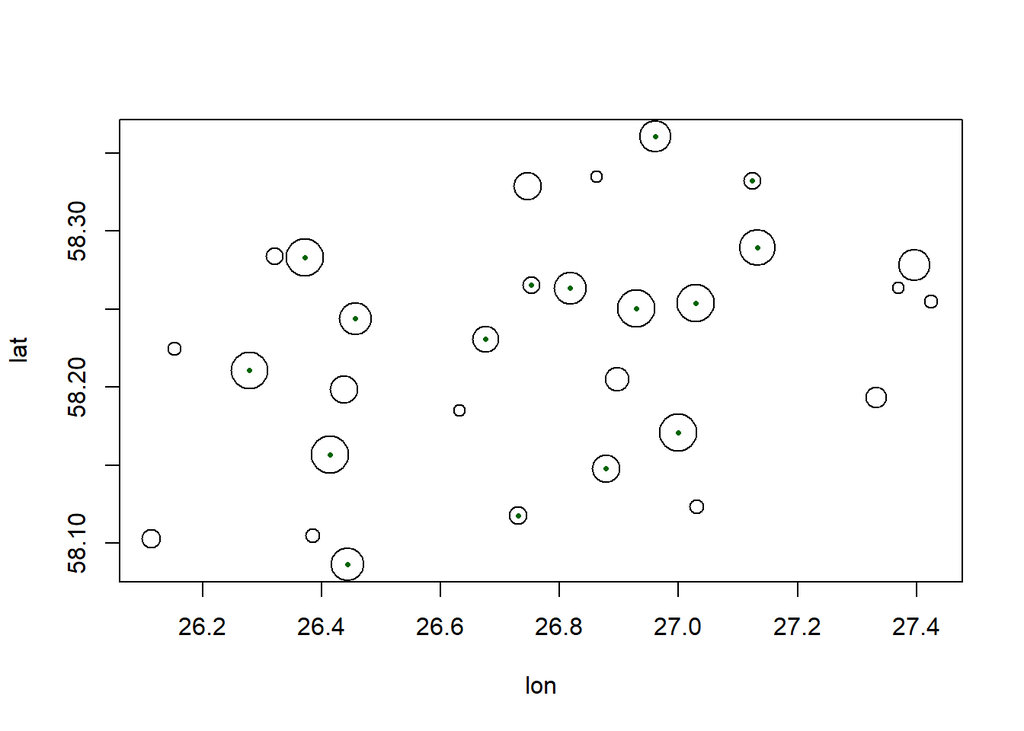

```r
# Now all soil data
m=glm(pa~.,soil.data[,-5],family=binomial) #~. means that all parameters from data are included
summary(m)
##
## Call:
## glm(formula = pa ~ ., family = binomial, data = soil.data[, -5])
##
## Coefficients:
##               Estimate Std. Error z value Pr(>|z|)
## (Intercept) -11.721287   4.923054  -2.381   0.0173 *
## pH.KCl        2.796036   1.124265   2.487   0.0129 *
## N..          -1.649511   3.110033  -0.530   0.5958
## P.mg.kg       0.099349   0.062678   1.585   0.1130
## K.mg.kg       0.002568   0.023451   0.110   0.9128
## ---
## Signif. codes:  0 '***' 0.001 '**' 0.01 '*' 0.05 '.' 0.1 ' ' 1
##
## (Dispersion parameter for binomial family taken to be 1)
##
##     Null deviance: 41.455  on 29  degrees of freedom
## Residual deviance: 24.174  on 25  degrees of freedom
## AIC: 34.174
##
## Number of Fisher Scoring iterations: 6
pr.glm=predict(m,type="response")

#Predicted distribution map
plot(xy[,-3],cex=pr.glm*2.5+1)
points(xy[pa>0,-3],pch=16,cex=0.5,col="darkgreen") # Actual presence-absence
```

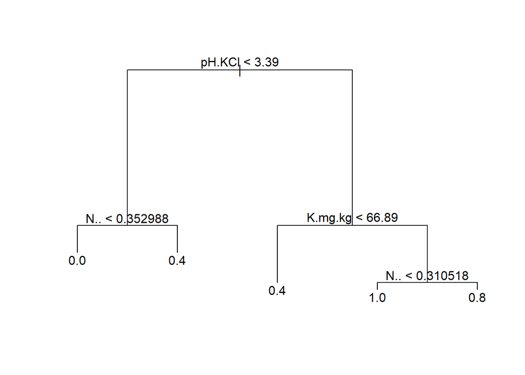

```r
# Regression trees can handle more complex relationships.
library(tree)

o.tree=tree(pa~.,data=soil.data[,-5])
plot(o.tree)
text(o.tree)
```

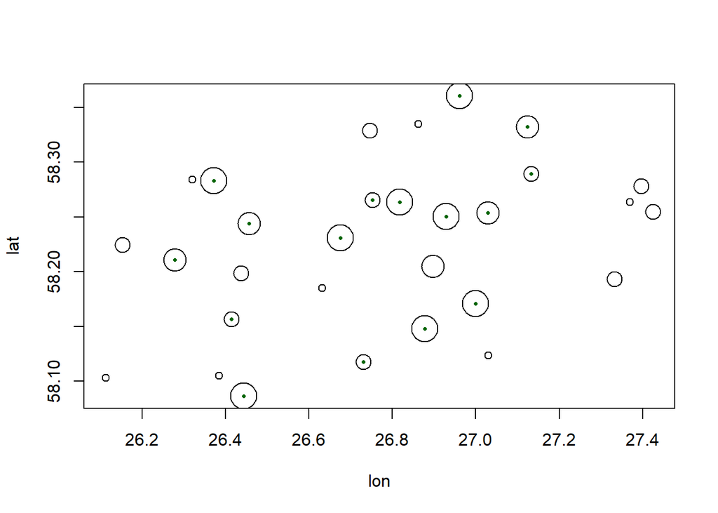

```r
pr.tree=predict(o.tree) # using the tree to predict

plot(xy[,-3],cex=pr.tree*2.5+1)
points(xy[pa>0,-3],pch=16,cex=0.5,col="darkgreen")
```

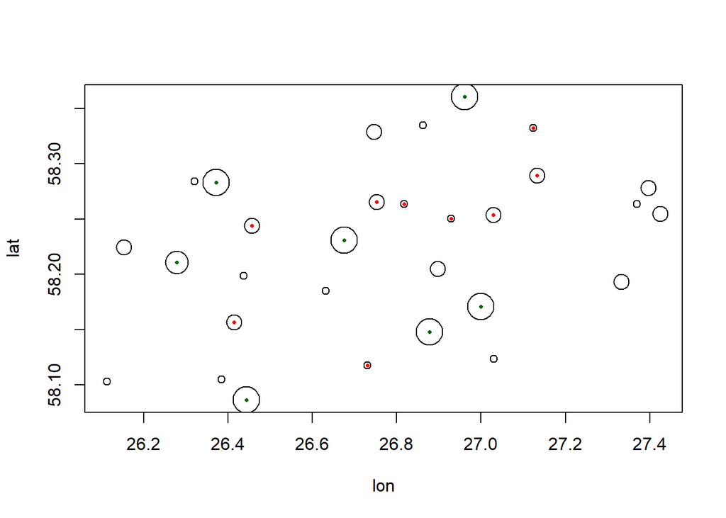

```r
## Scenarios for future changes

## drop of pH 0.5 units

new.soil=soil.data[,-5]
new.soil[,1]=new.soil[,1]-0.5
pr.tree.1=predict(o.tree,new.soil)
plot(xy[,-3],cex=pr.tree.1*2.5+1)
points(xy[pa>0,-3],pch=16,cex=0.5,col="darkgreen")

points(xy[pa>0 & pr.tree.1 < 0.5,-3],pch=16,cex=0.5,col="red")
```

```r
# Red points show sites where the species will have probability < 0.5 after environmental change (likely going extinct)
```

> Try a scenario when soil pH increases 0.5 units

**Answer**

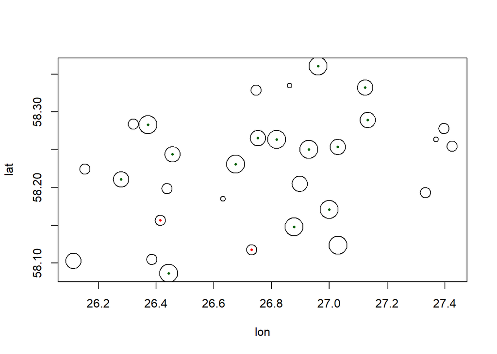

```r
new.soil=soil.data[,-5]
new.soil[,1]=new.soil[,1]+0.5
pr.tree.1=predict(o.tree,new.soil)
plot(xy[,-3],cex=pr.tree.1*2.5+1)
points(xy[pa>0,-3],pch=16,cex=0.5,col="darkgreen")

points(xy[pa>0 & pr.tree.1 < 0.5,-3],pch=16,cex=0.5,col="red")
```